# Business Forecasting Homework: Dublin Monthly Rainfall (1976-1999)

Your Name

October 12, 2026

# 1. Data

The data are monthly rainfall (mm) at the Dublin (Ringsend) weather station, January 1976 to December 1999 (288 months). The file has a 13-line text header, then columns `year, month, ind, rain, gdf, rd, wd`. We only need `rain`.

Some months are missing. Either the row is absent (e.g., parts of 1993, 1994, 1995 and 1998) or the row exists with a blank `rain` value (indicator `ind = 8`). To get a regular monthly time series, I first build the full 288-month calendar and then fill the gaps.

```r
raw <- read.csv("Dublin_Rainfall_1976-1999.csv", skip = 13,
                stringsAsFactors = FALSE, strip.white = TRUE)
raw$rain <- suppressWarnings(as.numeric(raw$rain))   # blanks become NA

# full calendar so absent months show up as NA
cal <- expand.grid(month = 1:12, year = 1976:1999)
dat <- merge(cal, raw[, c("year", "month", "rain")], by = c("year", "month"), all.x = TRUE)
dat <- dat[order(dat$year, dat$month), ]

n_missing <- sum(is.na(dat$rain))
n_missing
```

```
## [1] 38
```

There are **38** missing months out of 288. I fill them with `na.interp()`, which uses seasonal interpolation (it respects the monthly pattern rather than drawing a straight line). With only about 13.2% of months affected, this should not change the conclusions.

```r
rain_raw <- ts(dat$rain, start = c(1976, 1), frequency = 12)
rain     <- na.interp(rain_raw)

summary(as.numeric(rain))
```

```
##    Min. 1st Qu.  Median    Mean 3rd Qu.    Max.
##    0.90   34.05   54.39   57.61   75.33  259.00
```

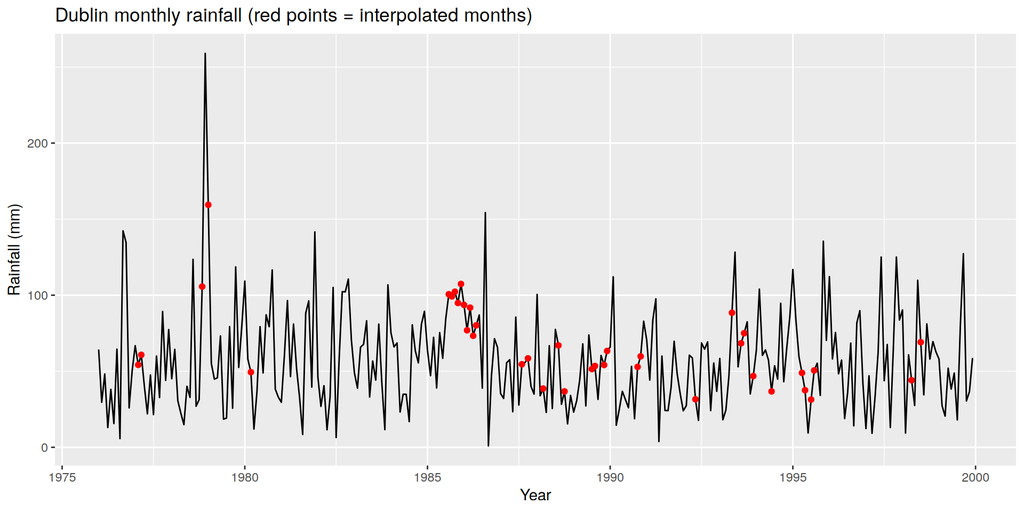

```r
imp <- data.frame(time = as.numeric(time(rain))[is.na(rain_raw)],
                  rain = as.numeric(rain)[is.na(rain_raw)])
autoplot(rain) +
  geom_point(data = imp, aes(x = time, y = rain), colour = "red", size = 1.5) +
  labs(title = "Dublin monthly rainfall (red points = interpolated months)",
       x = "Year", y = "Rainfall (mm)")
```

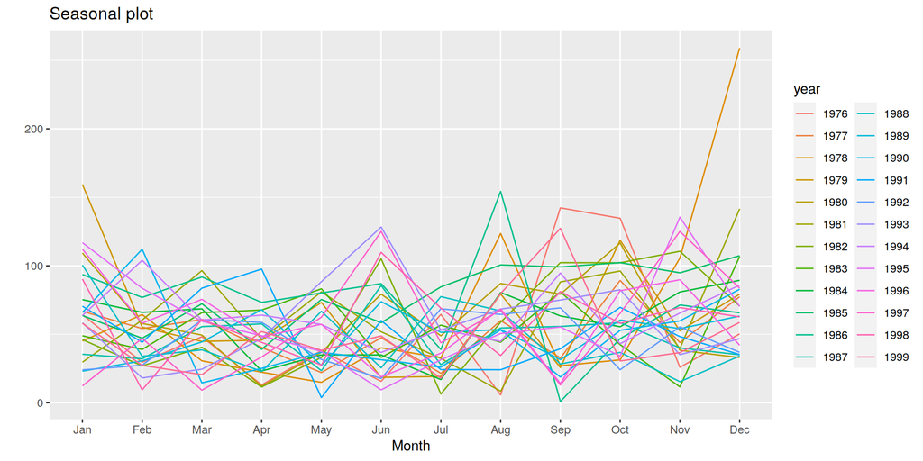

```r
ggseasonplot(rain, year.labels = FALSE) + labs(title = "Seasonal plot")
```

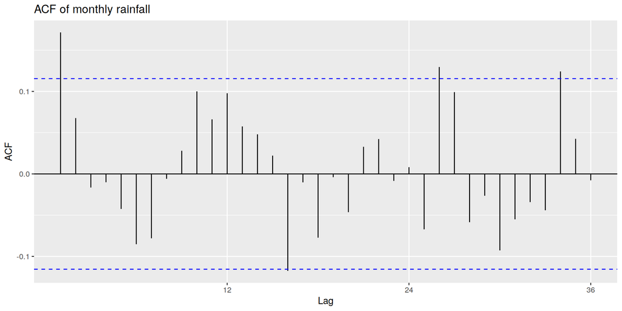

```r
ggAcf(rain, lag.max = 36) + labs(title = "ACF of monthly rainfall")
```

**What we see:** Rainfall bounces around a stable level with no clear upward or downward trend. There is a mild seasonal pattern (autumn/winter tend to be wetter than spring/early summer), but it is weak compared with the month-to-month noise. The ACF has small spikes, so past values contain little information about the next month. This tells us that fancy models will probably not beat simple ones by much.

# 2. Time series decomposition

Decomposition splits the series into **trend** (slow long-run movement), **seasonal** (a pattern repeating every 12 months) and **remainder** (everything left over). It is a way to see which of those components actually matter in this series. I use the full 1976-1999 series (with the gaps interpolated).

## 2.1 Classical additive decomposition

Additive form: `rain = trend + seasonal + remainder`. It is appropriate when the seasonal swings stay about the same size regardless of the level.

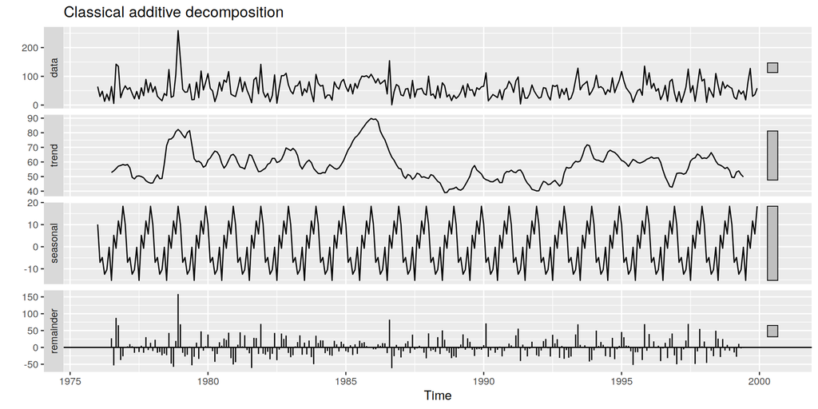

```r
dec_add <- decompose(rain, type = "additive")
autoplot(dec_add) + labs(title = "Classical additive decomposition")
```

## 2.2 Classical multiplicative decomposition

Multiplicative form: `rain = trend x seasonal x remainder`. It is appropriate when seasonal swings grow and shrink with the level.

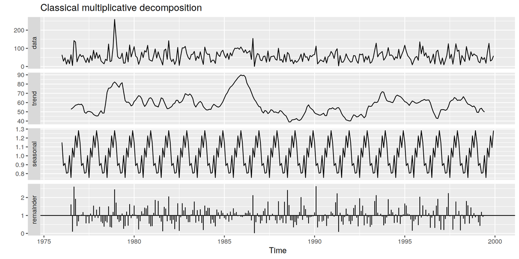

```r
dec_mult <- decompose(rain, type = "multiplicative")
autoplot(dec_mult) + labs(title = "Classical multiplicative decomposition")
```

## 2.3 STL decomposition (robust)

STL (Seasonal and Trend decomposition using Loess) is more flexible than the classical method: it handles any seasonality, gives a trend estimate at the ends of the series, and the `robust = TRUE` option stops unusually wet months from distorting the trend and seasonal estimates. Rainfall has some very large months (the maximum is about 259 mm), so robustness is useful here.

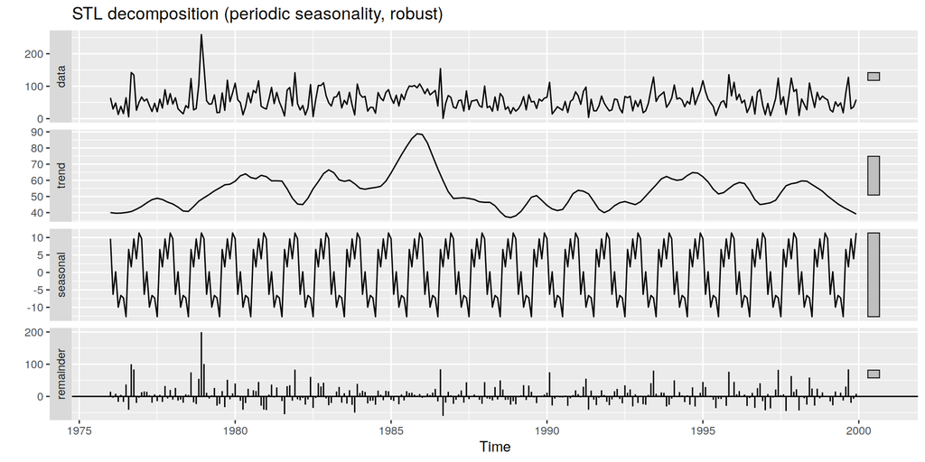

```r
dec_stl <- stl(rain, s.window = "periodic", robust = TRUE)
autoplot(dec_stl) + labs(title = "STL decomposition (periodic seasonality, robust)")
```

## 2.4 Reading the components

**Seasonal component.** The table shows the average effect of each month. The additive column is in mm above/below the trend. The multiplicative column is a ratio (1.10 means 10% above the trend).

```r
seas_tab <- data.frame(
  Month = month.abb,
  Additive_mm = as.numeric(dec_add$figure),
  Multiplicative_index = as.numeric(dec_mult$figure),
  STL_mm = as.numeric(dec_stl$time.series[1:12, "seasonal"])[order(cycle(rain)[1:12])]
)
kable(seas_tab, digits = 2, caption = "Estimated seasonal effect by month")
```

Estimated seasonal effect by month

| Month | Additive_mm | Multiplicative_index | STL_mm |
| --- | --- | --- | --- |
| Jan | 10.08 | 1.15 | 9.64 |
| Feb | -7.07 | 0.89 | -6.28 |
| Mar | -4.86 | 0.92 | 0.18 |
| Apr | -12.47 | 0.81 | -9.94 |
| May | -10.39 | 0.81 | -6.59 |
| Jun | -0.26 | 1.00 | -7.29 |
| Jul | -15.24 | 0.76 | -12.69 |
| Aug | 5.14 | 1.09 | 6.57 |
| Sep | -0.70 | 0.98 | 1.60 |
| Oct | 11.67 | 1.22 | 9.60 |
| Nov | 5.76 | 1.09 | 3.91 |
| Dec | 18.33 | 1.28 | 11.30 |

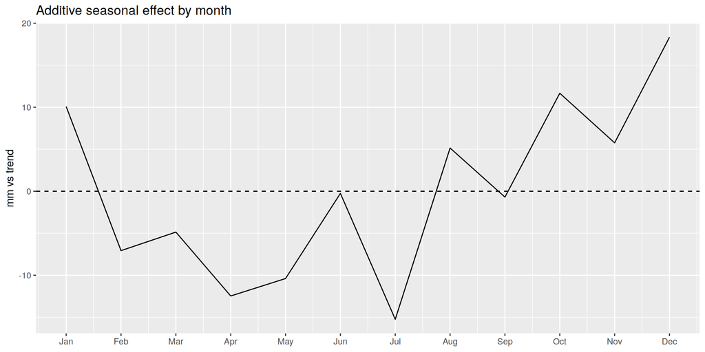

```r
autoplot(ts(dec_add$figure, start = 1, frequency = 1)) +
  scale_x_continuous(breaks = 1:12, labels = month.abb) +
  geom_hline(yintercept = 0, linetype = "dashed") +
  labs(title = "Additive seasonal effect by month", x = NULL, y = "mm vs trend")
```

**Trend component.** The STL trend, averaged by year:

```r
tr <- dec_stl$time.series[, "trend"]
trend_year <- aggregate(tr, nfrequency = 1, FUN = mean)
kable(data.frame(Year = floor(time(trend_year)), Trend_mm = round(as.numeric(trend_year), 1)),
      caption = "STL trend, annual mean (mm per month)")
```

STL trend, annual mean (mm per month)

| Year | Trend_mm |
| --- | --- |
| 1976 | 40.5 |
| 1977 | 47.0 |
| 1978 | 43.7 |
| 1979 | 54.4 |
| 1980 | 62.1 |
| 1981 | 56.8 |
| 1982 | 53.8 |
| 1983 | 61.0 |
| 1984 | 56.4 |
| 1985 | 78.7 |
| 1986 | 69.4 |
| 1987 | 48.3 |
| 1988 | 41.7 |
| 1989 | 45.5 |
| 1990 | 45.1 |
| 1991 | 47.4 |
| 1992 | 45.2 |
| 1993 | 55.8 |
| 1994 | 62.3 |
| 1995 | 55.6 |
| 1996 | 53.0 |
| 1997 | 51.6 |
| 1998 | 56.9 |
| 1999 | 44.3 |

**Remainder.** This is what trend and seasonality do not explain. Check it for leftover structure:

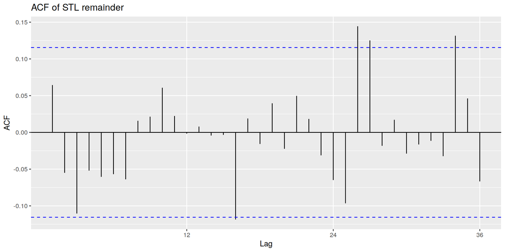

```r
rem_add  <- dec_add$random
rem_stl  <- dec_stl$time.series[, "remainder"]
ggAcf(rem_stl, lag.max = 36) + labs(title = "ACF of STL remainder")
```

## 2.5 Which components matter? (strength measures)

Following Hyndman and Athanasopoulos, the strength of trend and seasonality from STL is `F = max(0, 1 - Var(remainder) / Var(component + remainder))`. A value near 1 means a strong component; near 0 means weak.

```r
comp <- dec_stl$time.series
Ft <- max(0, 1 - var(comp[, "remainder"]) / var(comp[, "trend"]    + comp[, "remainder"]))
Fs <- max(0, 1 - var(comp[, "remainder"]) / var(comp[, "seasonal"] + comp[, "remainder"]))

share <- c(Trend = var(dec_add$trend, na.rm = TRUE),
           Seasonal = var(dec_add$seasonal),
           Remainder = var(dec_add$random, na.rm = TRUE)) / var(rain)

kable(data.frame(Measure = c("Trend strength (STL)", "Seasonal strength (STL)",
                             "Share of variance: trend (additive)",
                             "Share of variance: seasonal (additive)",
                             "Share of variance: remainder (additive)"),
                 Value = round(c(Ft, Fs, share), 3)))
```

| Measure | Value |
| --- | --- |
| Trend strength (STL) | 0.089 |
| Seasonal strength (STL) | 0.094 |
| Share of variance: trend (additive) | 0.102 |
| Share of variance: seasonal (additive) | 0.094 |
| Share of variance: remainder (additive) | 0.794 |

## 2.6 Additive vs multiplicative

```r
# Compare how "patternless" the remainders are: relative size of the remainder
cmp <- data.frame(
  Version = c("Additive", "Multiplicative"),
  Remainder_SD = c(sd(dec_add$random, na.rm = TRUE), sd(dec_mult$random, na.rm = TRUE)),
  Remainder_unit = c("mm", "ratio"),
  Ljung_Box_p = c(Box.test(na.omit(dec_add$random),  lag = 24, type = "Ljung")$p.value,
                  Box.test(na.omit(dec_mult$random), lag = 24, type = "Ljung")$p.value)
)
kable(cmp, digits = 3)
```

| Version | Remainder_SD | Remainder_unit | Ljung_Box_p |
| --- | --- | --- | --- |
| Additive | 29.124 | mm | 0.011 |
| Multiplicative | 0.493 | ratio | 0.033 |

## 2.7 Seasonally adjusted series

Removing the STL seasonal component shows the underlying level (trend + remainder):

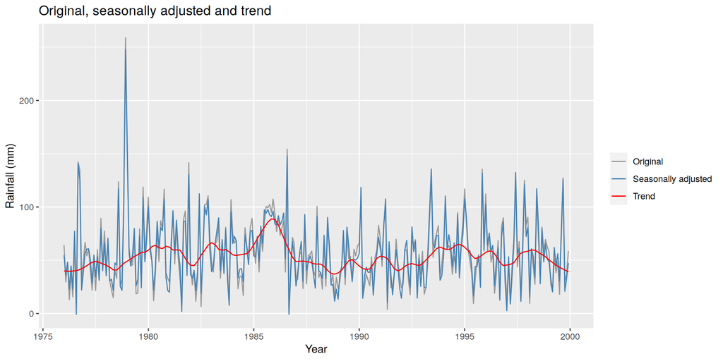

```r
autoplot(rain, series = "Original") +
  autolayer(seasadj(dec_stl), series = "Seasonally adjusted") +
  autolayer(dec_stl$time.series[, "trend"], series = "Trend") +
  scale_colour_manual(values = c("Original" = "grey60", "Seasonally adjusted" = "steelblue",
                                 "Trend" = "red")) +
  labs(title = "Original, seasonally adjusted and trend", x = "Year", y = "Rainfall (mm)",
       colour = NULL)
```

## 2.8 Sensitivity check: how the gap filling affects the trend

The STL trend peaks in 1985-1986 (annual mean near 79 mm in 1985). Part of this is an artifact: Aug 1985 to May 1986 is a run of 10 consecutive missing months, and `na.interp()` filled them with values around 100 mm, well above the typical 57 mm. As a check, I refill the gaps with each calendar month’s average and repeat STL.

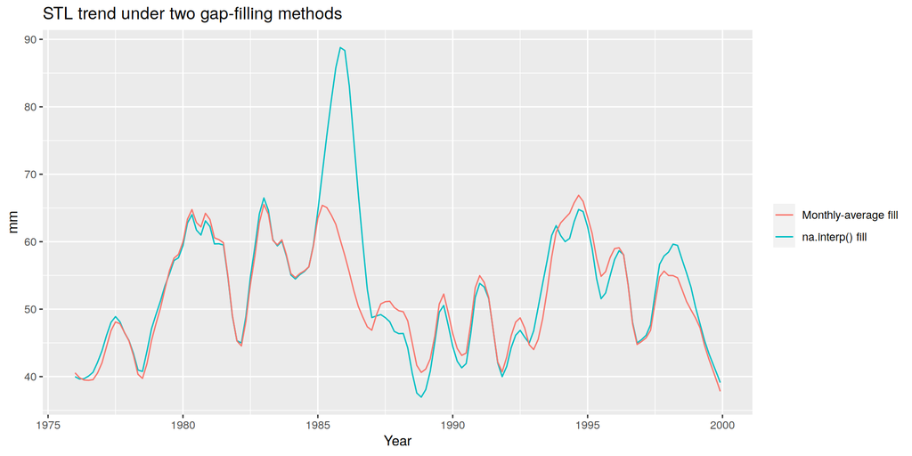

```r
mm  <- tapply(dat$rain, dat$month, mean, na.rm = TRUE)
alt <- dat$rain
alt[is.na(alt)] <- mm[dat$month[is.na(alt)]]
rain_alt <- ts(alt, start = c(1976, 1), frequency = 12)
stl_alt  <- stl(rain_alt, s.window = "periodic", robust = TRUE)
ca <- stl_alt$time.series
Ft_alt <- 1 - var(ca[, "remainder"]) / var(ca[, "trend"]    + ca[, "remainder"])
Fs_alt <- 1 - var(ca[, "remainder"]) / var(ca[, "seasonal"] + ca[, "remainder"])

autoplot(comp[, "trend"], series = "na.interp() fill") +
  autolayer(ca[, "trend"], series = "Monthly-average fill") +
  labs(title = "STL trend under two gap-filling methods", x = "Year", y = "mm", colour = NULL)
```

```r
kable(data.frame(Fill = c("na.interp()", "Monthly average"),
                 Trend_strength = round(c(Ft, Ft_alt), 3),
                 Seasonal_strength = round(c(Fs, Fs_alt), 3)))
```

| Fill | Trend_strength | Seasonal_strength |
| --- | --- | --- |
| na.interp() | 0.089 | 0.094 |
| Monthly average | 0.040 | 0.102 |

# 3. Train / test split

To compare forecasts fairly, I fit every model on the **training set (1976-1997)** and test it on the **last 24 months (1998-1999)**, which the models do not see.

```r
h     <- 24
train <- window(rain, end = c(1997, 12))
test  <- window(rain, start = c(1998, 1))
length(train); length(test)
```

```
## [1] 264
```

```
## [1] 24
```

# 4. Forecast models

I fit eight models.

| Model | Idea |
| --- | --- |
| Mean | Forecast = average of all training data |
| Naive | Forecast = last observed value |
| Seasonal naive | Forecast = value from the same month last year |
| Drift | Naive plus the average change over time (a straight line between first and last points) |
| MA(5) | Forecast = average of the last 5 months (flat) |
| MA(9) | Forecast = average of the last 9 months (flat) |
| ETS | Exponential smoothing; the best error/trend/seasonal form is picked automatically by AICc |
| ARIMA | Auto-selected seasonal ARIMA (included as an extra) |

```r
# helper: flat forecast from a trailing moving average of the last k observations
ma_fc <- function(y, k, h) {
  f <- mean(tail(y, k))
  ts(rep(f, h), start = tsp(y)[2] + 1/12, frequency = 12)
}

fc_mean  <- meanf(train, h = h)
fc_naive <- naive(train, h = h)
fc_snaive<- snaive(train, h = h)
fc_drift <- rwf(train, drift = TRUE, h = h)
fc_ma5   <- ma_fc(train, 5, h)
fc_ma9   <- ma_fc(train, 9, h)
fit_ets  <- ets(train)
fc_ets   <- forecast(fit_ets, h = h)
fit_arima<- auto.arima(train)
fc_arima <- forecast(fit_arima, h = h)
```

## 4.1 Understanding the output

### Moving averages

MA(k) averages the last k months, and that single number becomes the forecast for every future month. A larger k smooths more (less noise, slower to react). Here are the two flat forecasts:

```r
data.frame(Model = c("MA(5)", "MA(9)"),
           Forecast_mm = c(fc_ma5[1], fc_ma9[1])) |> kable(digits = 1)
```

| Model | Forecast_mm |
| --- | --- |
| MA(5) | 70.9 |
| MA(9) | 68.8 |

### ETS

```r
fit_ets
```

```
## ETS(M,N,A)
##
## Call:
##  ets(y = train)
##
##   Smoothing parameters:
##     alpha = 1e-04
##     gamma = 1e-04
##
##   Initial states:
##     l = 56.9157
##     s = 18.2345 3.5732 10.0261 0.6219 6.9452 -16.2065
##            -2.2668 -9.1891 -12.6316 -3.6253 -4.6721 9.1905
##
##   sigma:  0.5476
##
##      AIC     AICc      BIC
## 3296.141 3298.077 3349.780
```

The label `ETS(Error, Trend, Seasonal)` tells you the chosen form (A = additive, M = multiplicative, N = none). **alpha** is the smoothing weight on the level: values near 0 mean the level changes slowly and the forecast leans on the long-run average, values near 1 mean the forecast chases the latest observation. **gamma** (if present) does the same for the seasonal pattern.

*In my run:* ETS chose **(M,N,A)**: multiplicative errors, no trend, additive seasonality. Both alpha and gamma are essentially 0, so the level and the seasonal pattern are treated as almost fixed over time. In plain terms, the model forecasts “the long-run average (about 57 mm) plus a fixed seasonal adjustment for each month,” and does not chase recent observations. This matches the exploration: no trend, a stable level, and a mild seasonal pattern. AIC/AICc/BIC are fit-versus-complexity scores (lower is better); `sigma^2` is the residual variance.

### ARIMA

```r
fit_arima
```

```
## Series: train
## ARIMA(1,0,0)(1,0,0)[12] with non-zero mean
##
## Coefficients:
##          ar1    sar1     mean
##       0.1789  0.0813  57.8780
## s.e.  0.0608  0.0647   2.6222
##
## sigma^2 = 1055:  log likelihood = -1292.01
## AIC=2592.02   AICc=2592.18   BIC=2606.32
```

The `ARIMA(p,d,q)(P,D,Q)[12]` label gives the non-seasonal and seasonal autoregressive, differencing and moving-average orders. A model with no or few terms means the series is close to random noise around a mean (plus any seasonal term).

*In my run:* auto.arima picked **ARIMA(1,0,0)(1,0,0)[12] with non-zero mean**. No differencing (d = 0) confirms the series is stationary (no trend). The AR(1) coefficient (about 0.18) and seasonal AR coefficient (about 0.08) are small: this month’s rain explains only a little of next month’s, and last year’s same month explains even less. The mean is about 58 mm, so the forecasts quickly settle near that level.

### Residual check (ETS)

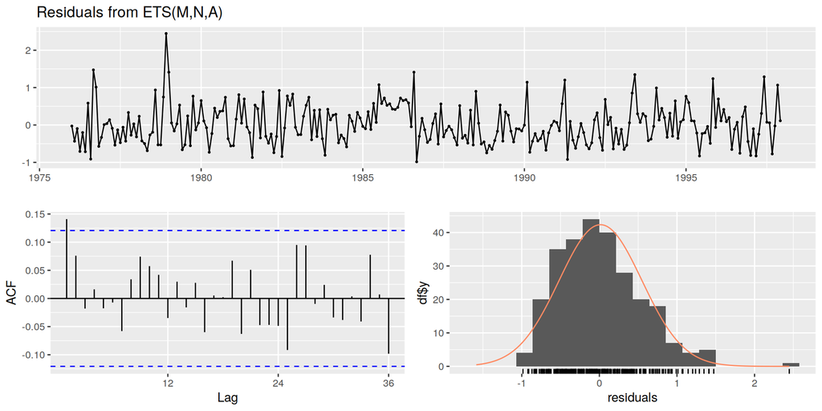

```
##
##  Ljung-Box test
##
## data:  Residuals from ETS(M,N,A)
## Q* = 18.319, df = 24, p-value = 0.7873
##
## Model df: 0.   Total lags used: 24
```

```r
checkresiduals(fit_ets)
```

If the residuals look like white noise (no significant ACF spikes, Ljung-Box p-value above 0.05), the model has captured the available pattern.

*In my run:* the Ljung-Box p-value is about 0.79, well above 0.05, so there is no evidence of leftover autocorrelation. The ETS residuals behave like white noise and the model is adequate.

# 5. All forecasts on one chart

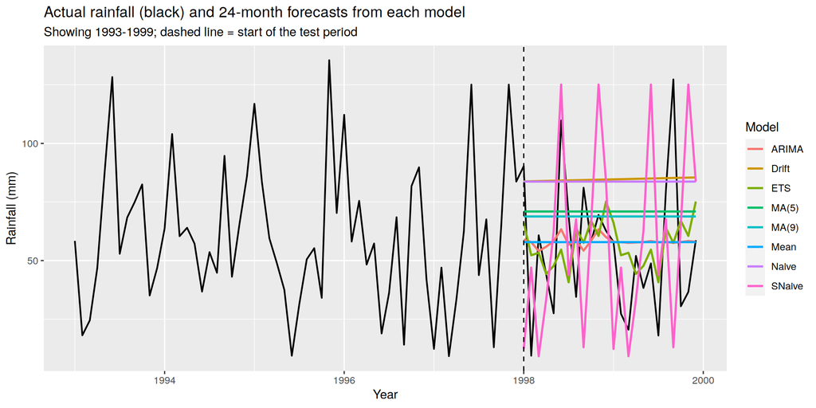

```r
fc_df <- data.frame(
  time  = as.numeric(time(test)),
  Mean  = as.numeric(fc_mean$mean),
  Naive = as.numeric(fc_naive$mean),
  SNaive= as.numeric(fc_snaive$mean),
  Drift = as.numeric(fc_drift$mean),
  `MA(5)` = as.numeric(fc_ma5),
  `MA(9)` = as.numeric(fc_ma9),
  ETS   = as.numeric(fc_ets$mean),
  ARIMA = as.numeric(fc_arima$mean),
  check.names = FALSE
)
fc_long <- reshape(fc_df, direction = "long",
                   varying = names(fc_df)[-1], v.names = "rain",
                   timevar = "Model", times = names(fc_df)[-1])

hist_df <- data.frame(time = as.numeric(time(window(rain, start = c(1993, 1)))),
                      rain = as.numeric(window(rain, start = c(1993, 1))))

ggplot() +
  geom_line(data = hist_df, aes(time, rain), colour = "black", linewidth = 0.7) +
  geom_line(data = fc_long, aes(time, rain, colour = Model), linewidth = 0.9) +
  geom_vline(xintercept = 1998, linetype = "dashed") +
  labs(title = "Actual rainfall (black) and 24-month forecasts from each model",
       subtitle = "Showing 1993-1999; dashed line = start of the test period",
       x = "Year", y = "Rainfall (mm)")
```

The flat lines (Mean, Naive, Drift, MA) cannot follow the seasonal ups and downs, while Seasonal naive, ETS and ARIMA (if they include seasonality) wiggle. The plot shows how all the forecasts sit relative to the actual 1998-1999 values.

# 6. Accuracy comparison

I use **RMSE** (root mean squared error) as the main measure. It is in the same units as the data (mm) and penalises large misses, which matter for rainfall. I also report MAE and MAPE for reference.

```r
act <- as.numeric(test)
acc <- function(pred) {
  e <- act - as.numeric(pred)
  c(RMSE = sqrt(mean(e^2)), MAE = mean(abs(e)), MAPE = mean(abs(e / act)) * 100)
}
acc_tab <- rbind(
  Mean = acc(fc_mean$mean),   Naive = acc(fc_naive$mean),
  `Seasonal naive` = acc(fc_snaive$mean), Drift = acc(fc_drift$mean),
  `MA(5)` = acc(fc_ma5), `MA(9)` = acc(fc_ma9),
  ETS = acc(fc_ets$mean), ARIMA = acc(fc_arima$mean)
)
acc_tab <- as.data.frame(acc_tab)
acc_tab <- acc_tab[order(acc_tab$RMSE), ]
kable(acc_tab, digits = 2, caption = "Test-set accuracy (1998-1999), sorted by RMSE")
```

Test-set accuracy (1998-1999), sorted by RMSE

|  | RMSE | MAE | MAPE |
| --- | --- | --- | --- |
| ETS | 27.56 | 22.34 | 64.77 |
| ARIMA | 28.20 | 22.17 | 71.06 |
| Mean | 28.51 | 22.40 | 71.29 |
| MA(9) | 31.67 | 26.23 | 91.26 |
| MA(5) | 32.67 | 27.38 | 95.73 |
| Naive | 40.55 | 35.37 | 124.11 |
| Drift | 41.24 | 36.12 | 126.24 |
| Seasonal naive | 47.70 | 38.96 | 91.15 |

```r
best <- rownames(acc_tab)[1]
```

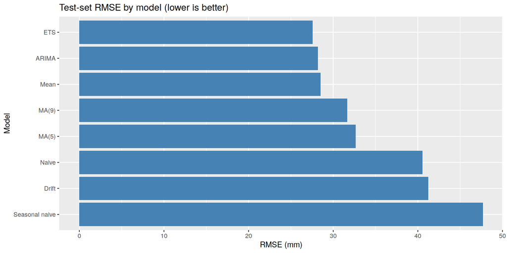

```r
ggplot(data.frame(Model = factor(rownames(acc_tab), levels = rev(rownames(acc_tab))),
                  RMSE = acc_tab$RMSE), aes(Model, RMSE)) +
  geom_col(fill = "steelblue") + coord_flip() +
  labs(title = "Test-set RMSE by model (lower is better)", y = "RMSE (mm)")
```

# 7. Conclusion

Based on RMSE on the 24-month hold-out set, the best model is **ETS** (RMSE = 27.56 mm).

Ranking by RMSE: ETS < ARIMA < Mean < MA(9) < MA(5) < Naive < Drift < Seasonal naive.